# MG205: Econometrics Theory and Applications

Topic 4: Statistical Inference

José Ignacio González-Rojas

j.i.gonzalez-rojas@lse.ac.uk

London School of Economics and Political Science

## Today We Test Whether Our Estimates Are Real

### All thirteen exercises, explained step by step

#### Testing claims (Q1–Q6)

- **Q1–Q4:** policy thresholds, regression tables, sign flips and certainty
- **Q5–Q6:** why we use the t-distribution, plus joint F-tests

#### Intervals and applications (Q7–Q13)

- **Q7–Q10:** confidence intervals, joint vs individual tests, precision
- **Q11–Q13:** non-zero nulls, interpreting intervals, full CEO case

Every idea is explained the first time it appears; later questions apply it

# **Exercise 1:** Point Estimates Are Not Decisions

## Q1: Bed nets cut malaria by 4 points, but must clear 3

### Field experiment in rural sub-Saharan Africa

- Households randomly receive bed nets (1) or not (0)
- **Policy rule:** roll out only with strong evidence malaria falls by **at least 3 percentage points**

$$\widehat{\text{malaria}_{i}}=\underset{(0.06)}{0.17}-\underset{(0.02)}{0.04}\,\mathbb{1}[\text{received bed net}_{i}]$$

- Malaria is on a **0–1 scale**; standard errors (SEs) are in parentheses
- Point estimate: **4 percentage points lower** (not 4% relative)

Should the programme go ahead?

## Q1: The evidence is not strong enough to proceed

### One-sided test at the 5% level

$$H_0:\beta_{\text{bed net}}\geq-0.03 \qquad\text{vs}\qquad H_1:\beta_{\text{bed net}}<-0.03$$

#### Test statistic

$$t=\frac{-0.04-(-0.03)}{0.02}=-0.50$$

- Normal 5% cutoff ($n$ not given): **$-1.645$**

#### Decision

- $-0.50>-1.645$ → **fail to reject $H_0$**
- **Do not proceed yet:** SE ($0.02$) is too large for a $0.01$ margin beyond 3 percentage points
- Failing to reject does **not prove** zero effect

# **Exercise 2:** Firm Size, Profits and CEO Pay

## Q2: What explains CEO pay across 209 firms?

### Outcome: log of CEO salary across 209 firms (SEs in parentheses)

| Regressor | Estimate | SE | Meaning |
| --- | --- | --- | --- |
| Intercept | 4.3 | 0.29 | Constant |
| Log sales | 0.27 | 0.03 | Log of company sales |
| Return on equity (ROE) | 0.018 | 0.003 | Profitability rate, **0–1 scale** |
| 3-year ROE change | 0.0005 | 0.0003 | **Percentage change** in ROE (3 years) |

- **Tasks:** (1) interpret sales & ROE; (2) test both at 5%; (3) keep 3-year ROE change?; (4) is $n=209$ too small to say anything?

## Q2: Match each interpretation to the variable’s units

### Holding the other variables fixed

#### Log salary on log sales

$$\Delta\widehat{\log(\text{salary}_i)}=0.27\,\Delta\log(\text{sales}_i)$$

- **Elasticity:** 1% higher sales → **0.27% higher salary**
- 10% higher sales → **2.7% higher salary**

#### Log salary on ROE (0–1 scale)

- ROE rises from $0.10$ to $0.11$, so $\Delta\text{ROE}_i=0.01$:

$$\Delta\widehat{\log(\text{salary}_i)}=0.018(0.01)=0.00018$$

- **0.018% higher salary** — **not 1.8%**

Both are sample associations, not automatically causal effects

## Q2: Sales and ROE are significant; ROE growth is not

### Two-sided tests of $H_0:\beta_j=0$ vs $H_1:\beta_j\neq 0$ (holding other variables fixed)

- Degrees of freedom: $df = 209 - 3 - 1 = 205$ → 5% cutoff $t_{205,0.975}\simeq 1.972$

| Coefficient | Calculation | $t$ | Decision at 5% |
| --- | --- | --- | --- |
| Log sales | $0.27/0.03$ | 9.00 | Reject zero |
| ROE | $0.018/0.003$ | 6.00 | Reject zero |
| 3-year ROE change | $0.0005/0.0003$ | 1.67 | Fail to reject |

- **Keep 3-year ROE change?** Not for statistical significance alone ($|1.67| < 1.972$)
- Failing to reject does **not prove** zero effect — keep it if theory says it belongs as a control

## Q2: 209 firms is not “too small” to find an effect

### Sample size is already built into the standard error

$$\operatorname{Var}(\hat\beta_j\mid\mathbf{x})=\frac{\sigma^2}{\sum_{i=1}^{n}(x_{ij}-\bar x_j)^2(1-R_j^2)}$$

- **Claim is false:** the reported SEs already reflect $n = 209$
- More comparable, informative observations can shrink SEs; $R_j^2$ measures how well the other regressors explain regressor $j$
- **Proof in the table:** we reject zero for sales ($t = 9.00$) with 209 firms
- Still, $n=209$ alone does not guarantee a representative sample or valid model

# **Exercise 3:** Adding a Control Flips the Sign

## Q3: Controlling for z turns the slope from +0.02 to −0.07

### Numbers in parentheses are t-statistics, not standard errors

#### Short regression (without $z_i$)

$$\hat y_i=\underset{(2.2)}{0.02}+\underset{(0.70)}{0.02}x_i$$

- Positive slope, weak evidence: $t=0.70$

#### Long regression (controlling for $z_i$)

$$\hat y_i=\underset{(2.1)}{0.34}-\underset{(-2.7)}{0.07}x_i-\underset{(-3.1)}{0.50}z_i$$

- Negative slope holding $z_i$ fixed: $t=-2.7$
- **Questions:** Can we **categorically** rule out a positive link? Was the short slope biased, by how much, and how are $x$ and $z$ correlated?

## Q3: A negative estimate is evidence, not certainty

### Keep statistical uncertainty separate from model choice

- **Without $z$:** $t=0.70$ → fail to reject zero
- **With $z$:** $t=-2.7$ → reject zero at 5% (normal cutoff $\pm 1.96$, since $n$ is not given)
- **Can we rule out a positive effect *categorically*?** **No** — a 5% test controls error rates, never gives 100% certainty
- **Reminder:** controlling for $z$ does not automatically make the slope causal

## Q3: The +0.09 gap reveals a negative link between x and z

### Omitted-variable bias formula on the same sample

$$\begin{align*}
\hat\beta_x^{\text{short}}-\hat\beta_x^{\text{long}}
&=\hat\beta_z^{\text{long}}\hat\delta_1\\
0.02-(-0.07)&=(-0.50)\hat\delta_1\\
\hat\delta_1&=-0.18.
\end{align*}$$

- **Gap (short minus long):** **$+0.09$** (estimated bias if long model holds)
- Regressing $z_i$ on $x_i$ gives slope $-0.18$
- **Sample correlation between $x$ and $z$ is negative**

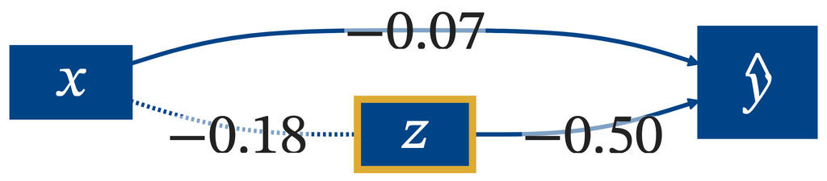

- Solid arrows: fitted slopes in long regression
- Dashed line: sample link between $x$ and $z$ (not causal)

Calling +0.09 “bias” assumes the long model is the valid model

## Q4: We never need 100% certainty to reject a null

### Applying Q1 and Q3 to tax breaks and IT patents

#### The TV interviewer’s claim

- Lower taxes strongly predict more patents among small IT firms
- Estimate assumed unbiased; SEs are tiny
- *“Your data are still possible under no effect — you can never be 100% sure.”*

#### How to reply

- **Statistics never promises 100% proof:** it bounds our error rate
- **p-value:** *if there were no effect, how rare would data this extreme be?* (not the chance $H_0$ is true)
- Policy also requires benefits large enough to justify tax costs (Q1)

# **Exercise 5:** Why We Use the t-Distribution

## Q5: Knowing beta-hat is normal is not enough to run a test

### The variance formula contains an unknown number

- Classical normal model: $y_i=\beta_0+\beta_1 x_{i1}+\dots+\beta_k x_{ik}+e_i$, with independent normal errors $e_i\sim N(0,\sigma^2)$ given $\mathbf{x}$
- Let $D_j=\sum_{i=1}^{n}(x_{ij}-\bar x_j)^2(1-R_j^2)$

#### What we are given

$$\hat\beta_j\mid\mathbf{x}\sim N\left(\beta_j,\frac{\sigma^2}{D_j}\right)$$

- Second slot is a **variance**, not an SE
- In real data, $\sigma^2$ is **unknown**

#### If we knew sigma

$$Z=\frac{\hat\beta_j-\beta_{j,0}}{\sigma/\sqrt{D_j}}\sim N(0,1)$$

- Under $H_0:\beta_j=\beta_{j,0}$
- Without $\sigma$, we cannot calculate $Z$

## Q5: Estimating error variance gives the t-distribution

### Replacing sigma with sigma-hat adds noise and widens the tails

#### 1. Estimate $\sigma^2$ ($df=n-k-1$)

$$\hat\sigma^2=\frac{\sum_i\hat\varepsilon_i^2}{n-k-1},\qquad \operatorname{SE}(\hat\beta_j)=\frac{\hat\sigma}{\sqrt{D_j}}$$

- $U=\frac{(n-k-1)\hat\sigma^2}{\sigma^2}\sim\chi^2_{n-k-1}$, independent of $Z$

#### 2. Form the t-statistic

$$\begin{aligned}
T &= \frac{Z}{\sqrt{U/(n-k-1)}} \\
&= \frac{\hat\beta_j-\beta_{j,0}}{\operatorname{SE}(\hat\beta_j)} \sim t_{n-k-1}
\end{aligned}$$

- Wider tails reflect extra uncertainty from estimating $\sigma$
- To run a test, also specify $H_0$, $H_1$, and level $\alpha$

# **Exercise 6:** Testing Two Variables Together

## Q6: Do company tenure and CEO tenure matter together?

### Two regressions on the same 106 firms (outcome: log CEO salary)

| Regressor | Restricted model | Unrestricted model |
| --- | --- | --- |
| Intercept | 4.4 | 4.2 |
| Log sales | 0.11 | 0.12 |
| Log market value | 0.19 | 0.19 |
| Profit margin (percentage points) | −0.014 | −0.001 |
| Firm tenure (years) | Excluded | −0.002 |
| CEO tenure (years) | Excluded | 0.02 |
| **Sum of squared residuals (SSR)** | **27** | **25** |

- **Task:** state $H_0$ and $H_1$, and test whether both tenure variables belong in the model together

## Q6: The joint F-test rejects zero at the 5% level

### Comparing how much SSR drops when we add $q=2$ variables

$$H_0:\beta_{\text{firm tenure}}=\beta_{\text{CEO tenure}}=0, \qquad H_1:\text{at least one is non-zero}$$

#### Compute the F-statistic

- Unrestricted slopes $k=5$, so $df = 106 - 5 - 1 = 100$

$$\begin{aligned}
F&=\frac{(\mathrm{SSR}_r-\mathrm{SSR}_{ur})/q}{\mathrm{SSR}_{ur}/(n-k-1)}\\
&=\frac{(27-25)/2}{25/100}=4
\end{aligned}$$

#### Compare with $F_{2,100}$

- 5% cutoff: **approx. 3.09**
- $4>3.09$ → **reject $H_0$**
- At least one tenure slope is non-zero (not necessarily both, or causal)

# **Part 2:** Confidence Intervals and Precision

## Q7: Work, sleep and confidence intervals

### Outcome: weekly sleep (minutes/week) across all 532 law-firm associates

| Regressor | Estimate | SE | Units |
| --- | --- | --- | --- |
| Intercept | 3672 | 128 | Sleep minutes/week |
| Work | −0.152 | 0.020 | Work minutes/week |
| Education | −11.2 | 7.14 | Years |
| Log wage | −20.4 | 30.4 | Log of wage |
| Age | 0.80 | 1.64 | Years |

- **Tasks:** **(a)** interpret work & log wage; **(b)** build & interpret 95% CIs for work & education; **(c)** compare with 90% CIs; **(d)** can we test $\beta_{\text{education}}=0$ without running a t-test?

## Q7 (a): Watch the units — minutes per week vs log wage

### Holding education, wage and age fixed

#### Work (minutes per week)

$$\Delta\widehat{\text{sleep}_i}=-0.152\,\Delta\text{work}_i$$

- **+1 minute** of work/week → **0.152 fewer minutes** of sleep/week
- **+1 hour** of work/week → $60(0.152)=9.12$ fewer minutes of sleep/week

#### Log wage (level–log)

$$\Delta\widehat{\text{sleep}_i}=-20.4\,\Delta\log(\text{wage}_i)$$

- **+1% wage** ($\Delta\log(\text{wage}_i)\simeq 0.01$):
- $-20.4(0.01)=-0.204$ sleep minutes/week
- **Not** 20.4 fewer minutes of sleep

## Q7 (b–d): 95% and 90% confidence intervals

### Same estimate and SE; only the critical value changes

$$\text{CI}=\left[\hat\beta_j-c\,\operatorname{SE}(\hat\beta_j),\ \hat\beta_j+c\,\operatorname{SE}(\hat\beta_j)\right]$$

- $df = 532 - 4 - 1 = 527$; normal approximations: **$c \simeq 1.96$** (95%) and **$c \simeq 1.645$** (90%)

| Parameter | 95% interval | 90% interval |
| --- | --- | --- |
| Work | $[-0.1912,-0.1128]$ | $[-0.1849,-0.1191]$ |
| Education | $[-25.1944,2.7944]$ | $[-22.9453,0.5453]$ |

- **Why is 90% narrower?** Smaller $c$ gives a tighter range, but misses the true slope more often (10% vs 5%)
- **Test for education ($H_0:\beta_{\text{education}}=0$):** **fail to reject** at 5% and 10% — $0$ lies inside both intervals

## Q7: What does “95% confidence” actually mean?

### The true slope is fixed; the interval changes from sample to sample

#### Before we draw a sample

- The estimate and SE depend on random data, so the interval is random
- **95% of intervals built this way** cover the fixed true slope across repeated samples

#### After we compute our numbers

- $[-0.1912,-0.1128]$ is a fixed pair of numbers
- The true slope is either inside or outside — **not** a 95% probability for this one interval

The interval is about the slope $\beta_{\text{work}}$, not 95% of individual associates

## Q8: Is the widest confidence interval always best?

### Applying Q7: $\text{Width}=2c\,\operatorname{SE}(\hat\beta_j)$

- **Claim:** *“Make confidence intervals as wide as possible so we are almost sure they contain the true parameter.”*

#### Why the claim fails

- $(-\infty,+\infty)$ always covers the parameter, yet tells us **nothing**
- Higher confidence ($c\uparrow$) buys coverage only by losing precision

#### What we do instead

- Pick a stated confidence level (e.g. 95%)
- To narrow the interval without losing confidence, **reduce the SE**, not $c$

Q7 90% intervals are narrower because $c$ fell, not because precision improved

## Q9: Two regressions for 100 Japanese firms

### Outcome: log of CEO salary (with and without tenure)

| Regressor | Restricted model | Unrestricted model |
| --- | --- | --- |
| Intercept | 4.4 | 4.2 |
| Log sales | 0.11 | 0.12 |
| Log market value | 0.19 | 0.19 |
| Profit margin (percentage points) | −0.014 | −0.001 |
| Firm tenure (years) | Excluded | −0.002 |
| CEO tenure (years) | Excluded | 0.02 |
| **SSR / Reported $R^2$** | **18.34 / 0.48** | **16.76 / 0.52** |

## Q9 (a–b): Apply Q6 joint F-test to the 100 Japanese firms

### Same hypotheses, new sample size ($df = 100 - 5 - 1 = 94$)

$$H_0:\beta_{\text{firm tenure}}=\beta_{\text{CEO tenure}}=0, \qquad H_1:\text{at least one is non-zero}$$

$$F=\frac{(18.34-16.76)/2}{16.76/94}\simeq 4.43 > 3.09$$

- **5% cutoff ($F_{2,94}$):** approx. **3.09** ($p\simeq 0.014$) → **reject $H_0$**
- Use the supplied SSRs directly (plugging in rounded $R^2$ values gives rounding error)

## Q9: Why can individual tests fail when the joint test passes?

### Individual p-values are 0.27 (firm tenure) and 0.35 (CEO tenure)

#### The puzzle

- Neither tenure slope is significant on its own ($0.27>0.05$, $0.35>0.05$)
- Yet the joint F-test rejects ($F\simeq 4.43$, $p\simeq 0.014$)

#### Why there is no contradiction

- If tenure measures move closely together (**collinearity**), separate slopes can be hard to estimate
- Individual tests isolate one holding the other fixed → large SEs
- The F-test checks their **combined** explanatory power

The F-test is **not immune** to multicollinearity — and rejecting $H_0$ does not prove both matter

## Q10: How do we get a narrow interval at high confidence?

### Energy prices, steel profits, and an unlimited data budget

- **Goal:** a **narrow range** that captures the true link with high confidence; money is no object

#### Do not lower confidence

- $\text{Width}=2c\,\operatorname{SE}(\hat\beta_j)$
- Lowering $c$ narrows the interval only by sacrificing confidence (Q8)

#### Shrink the standard error instead

- Spend the budget on a **much larger, clean dataset**
- With comparable independent data, $\operatorname{SE}(\hat\beta_j)\propto n^{-1/2}$: **4× observations can halve the width**
- More data cut noise, **not** omitted-variable bias

# **Part 3:** New Nulls and Putting It All Together

## Q11: A printed p-value only tests $H_0: \beta = 0$

### R&D spending and sales (p-values in square brackets)

$$\widehat{\log(\text{R\&D expenditure}_{i})}=\underset{[0.00]}{3.9}+\underset{[0.009]}{1.07}\log(\text{sales}_{i})$$

- Brackets show **zero-null p-values**, not SEs ($0.00$ is rounded, not literally zero)
- Neither the SE nor sample size ($df$) is supplied
- **Questions:** Can we reject $\beta_{\log(\text{sales})}=1$? What about $\beta_{\log(\text{sales})}=-1$?

## Q11: One estimate, three possible null hypotheses

### Illustrative curves: same assumed SE; its value is not supplied

[figure not shown]

## Q11: Compare distances using the same standard error

### Applying Q1: $t(b)=\frac{1.07-b}{\operatorname{SE}(\hat\beta)}$

| Null $b$ | Distance $\|1.07-b\|$ | What follows |
| --- | --- | --- |
| $0$ | 1.07 | Reported p-value is 0.009 |
| $1$ | 0.07 | The reported p-value alone does not determine this test |
| $-1$ | 2.07 | Farther away; larger $\|t\|$ → $p < 0.009$ → **reject at 1%** |

- **Caution:** $0.07$, $1.07$ and $2.07$ are distances in slope units, **not** numbers of standard errors

## Q12: Spot the mistake in this confidence interval claim

### Applying what we learned in Q7

- **Claim:** *“A 95% CI is a fixed interval; with 95% probability the random parameter lies inside it.”*

#### What is backwards

- The **population parameter is fixed**, not random
- Before sampling, the **interval is random** because it depends on the sample

#### Correct statement

- *“Across repeated samples, 95% of intervals built this way cover the fixed parameter.”*
- Once numbers are calculated, the parameter is either in or out

## Q13: Full CEO salary regression across 5,000 firms

### Outcome: log CEO salary; [p-values] in brackets, (SEs) in parentheses

| Regressor | Estimate | SE | Reported p-value |
| --- | --- | --- | --- |
| Intercept | 4.5 | 0.81 | 0.00 |
| Log sales | 0.18 | 0.05 | 0.00 |
| Log market value | 0.09 | 0.05 | 0.04 |
| Profit margin (percentage points) | −0.002 | 0.002 | 0.29 |
| Firm tenure (years) | −0.09 | 0.04 | 0.006 |
| CEO tenure (years) | 0.02 | 0.005 | 0.002 |

- **Tasks:** **(a)** interpret sales & firm tenure; **(b)** which slopes differ from zero?; **(c)** 95% CI for firm tenure; **(d)** outline a joint test of profit margin & CEO tenure

## Q13 (a–b): Interpreting slopes and checking significance

### Applying Q2 unit rules and reading reported p-values

#### (a) Interpret sales and firm tenure

- **Log sales ($0.18$):** 1% higher sales → **0.18% higher salary**
- **Firm tenure ($-0.09$):** +1 year → **about 9% lower salary** (exact: $100(e^{-0.09}-1)\simeq -8.61\%$), holding CEO tenure & controls fixed
- Watch the minus sign: longer firm tenure predicts **lower** pay here

#### (b) Significant at 5%?

- Using the **reported p-value column**:
- **Reject zero ($p<0.05$):** intercept ($0.00$), log sales ($0.00$), log market value ($0.04$), firm tenure ($0.006$), CEO tenure ($0.002$)
- **Fail to reject:** profit margin ($p=0.29$)
- Significance does not prove causation

## Q13 (c): 95% confidence interval for firm tenure

### Displayed estimate (−0.09), SE (0.04) and $df = 5000 - 5 - 1 = 4994$

$$-0.09\pm 1.96(0.04)=[-0.1684,-0.0116]$$

- **Meaning:** roughly $-16.8\%$ to $-1.2\%$ salary per extra year of firm tenure (exact: $-15.50\%$ to $-1.15\%$), using a procedure with 95% coverage (Q7)
- **Source check:** $-0.09/0.04=-2.25$ does not reproduce $p=0.006$; check the original output
- Keep inputs clean: use reported p-values for (b), and displayed estimate/SE for (c)

## Q13 (d): Outline a joint test for profit margin and CEO tenure

### Applying the F-test recipe from Q6

$$H_0:\beta_{\text{profit margin}}=\beta_{\text{CEO tenure}}=0, \qquad H_1:\text{at least one is non-zero}$$

- **Step 1:** keep the full 5-slope model on all **5,000** firms ($\mathrm{SSR}_{ur}$)
- **Step 2:** re-estimate the **restricted model** without profit margin and CEO tenure on the **same 5,000 firms** ($\mathrm{SSR}_r$)
- **Step 3:** compute $F=\frac{(\mathrm{SSR}_r-\mathrm{SSR}_{ur})/2}{\mathrm{SSR}_{ur}/4994}$ and compare with $F_{2,4994}$ ($5\%$ cutoff $\simeq 3.00$)
- **Missing inputs:** neither SSRs nor coefficient covariance are in the table, so **the exact F-statistic and joint p-value cannot be calculated from this table alone**

## Where Each Core Idea Appears First

### Complete map across all thirteen exercises

| First taught | Core idea | Applied later in |
| --- | --- | --- |
| Q1 | Relevant null; evidence vs certainty | Q2, Q3, Q4, Q11 |
| Q2 | Units, holding fixed, SEs already reflect $n$ | Q7, Q9, Q10, Q13 |
| Q5 | Unknown $\sigma^2$ leads to the t-distribution | Q6, Q7, Q13 |
| Q6 | Joint F-test (not separate t-tests) | Q9, Q13 |
| Q7 | Confidence intervals, coverage and duality | Q8, Q10, Q12, Q13 |

Adapted from Jordi Blanes i Vidal, *Class Exercises 4*, MG205.